# MLEARN 520 - Lesson 9 - Louis Duran

In this assignment, you will use `LIME` library to perform local explanations using surrogate modelsto explain the results of Random Forest Classifier models.

```python
#pip install plotly
#!pip install lime

# From Chen Wei. https://www.kaggle.com/code/prashant111/explain-your-model-predictions-with-lime
```

```python
import pandas as pd
import numpy as np
from sklearn.ensemble import RandomForestClassifier
from sklearn.model_selection import train_test_split
np.random.seed(0)
import matplotlib.pyplot as plt
import seaborn as sns
import plotly
import matplotlib
matplotlib.rcParams['figure.figsize'] = [10, 7]

# warnings.filterwarnings('ignore')
import lime
import lime.lime_tabular

df_data = pd.read_csv('music.xls')
df_data.head()
```

|  | artist.familiarity | artist.hotttnesss | artist.id | artist.latitude | artist.location | artist.longitude | artist.name | artist.similar | artist.terms | artist.terms_freq | ... | song.mode | song.mode_confidence | song.start_of_fade_out | song.tatums_confidence | song.tatums_start | song.tempo | song.time_signature | song.time_signature_confidence | song.title | song.year |
| --- | --- | --- | --- | --- | --- | --- | --- | --- | --- | --- | --- | --- | --- | --- | --- | --- | --- | --- | --- | --- | --- |
| 0 | 0.581794 | 0.401998 | ARD7TVE1187B99BFB1 | 0.00000 | 0 | 0.00000 | Casual | 0.0 | hip hop | 1.000000 | ... | 0 | 0.636 | 218.932 | 0.779 | 0.28519 | 92.198 | 4.0 | 0.778 | 0 | 0 |
| 1 | 0.630630 | 0.417500 | ARMJAGH1187FB546F3 | 35.14968 | 0 | -90.04892 | The Box Tops | 0.0 | blue-eyed soul | 1.000000 | ... | 0 | 0.430 | 137.915 | 0.969 | 0.20627 | 121.274 | 4.0 | 0.384 | 0 | 1969 |
| 2 | 0.487357 | 0.343428 | ARKRRTF1187B9984DA | 0.00000 | 0 | 0.00000 | Sonora Santanera | 0.0 | salsa | 1.000000 | ... | 1 | 0.565 | 172.304 | 0.482 | 0.42132 | 100.070 | 1.0 | 0.000 | 0 | 0 |
| 3 | 0.630382 | 0.454231 | AR7G5I41187FB4CE6C | 0.00000 | 0 | 0.00000 | Adam Ant | 0.0 | pop rock | 0.988584 | ... | 1 | 0.749 | 217.124 | 0.601 | 0.56254 | 119.293 | 4.0 | 0.000 | 0 | 1982 |
| 4 | 0.651046 | 0.401724 | ARXR32B1187FB57099 | 0.00000 | 0 | 0.00000 | Gob | 0.0 | pop punk | 0.887288 | ... | 1 | 0.371 | 198.699 | 1.000 | 0.13576 | 129.738 | 4.0 | 0.562 | 0 | 2007 |

5 rows × 35 columns

Question 1.1: Create the target of popular artists where artist familiarity is greater than 0.8 and artist hotttness is greater than 0.6.

```python
filtered_artists = df_data[(df_data['artist.familiarity'] > 0.8) & (df_data['artist.hotttnesss'] > 0.6)]
filtered_artists = filtered_artists['artist.name']


df_data['class'] = filtered_artists
df_data

#Use Grouby on class and count artist.id
df_data.groupby('class').count()['artist.id']

df_data = df_data.dropna()
```

Question 1.2: Train a Random Forest Classifier with 100 estimators considering these variables:

- vars_keep = ['song.bars_confidence', 'song.bars_start', 'song.beats_confidence', 'song.beats_start', 'song.duration', 'song.end_of_fade_in', 'song.hotttnesss', 'song.key_confidence', 'song.loudness', 'song.mode', 'song.mode_confidence', 'song.start_of_fade_out', 'song.tatums_confidence', 'song.tatums_start', 'song.tempo', 'song.time_signature', 'song.time_signature_confidence']

```python
vars_keep = ['song.bars_confidence', 'song.bars_start', 'song.beats_confidence', 'song.beats_start', 'song.duration', 'song.end_of_fade_in', 'song.hotttnesss', 'song.key_confidence', 'song.loudness', 'song.mode', 'song.mode_confidence', 'song.start_of_fade_out', 'song.tatums_confidence', 'song.tatums_start', 'song.tempo', 'song.time_signature', 'song.time_signature_confidence']
X, y = df_data[vars_keep], df_data['class']
X_train, X_test, Y_train, Y_test = train_test_split(X, y, test_size = 0.2, random_state = 0)
print('Training set size - X_train: {} '.format(X_train.shape))
print('Training set size - X_test: {} '.format(X_test.shape))

#RandomForestClassifier n_estimates =100, oob_score = True, random_state = 123456
rf = RandomForestClassifier(n_estimators = 100, oob_score = True, random_state = 123456)
rf.fit(X_train, Y_train)
```

```
Training set size - X_train: (316, 17)
Training set size - X_test: (79, 17)
```

```
RandomForestClassifier(oob_score=True, random_state=123456)
```

Question 2.1: Initializing the LIME explainer. You need to include the following conditions - feature_names, class_names, verbose, discretize_continuous, and mode. It is important to note that when you tune class_name that the order is important.

```python
explainer = lime.lime_tabular.LimeTabularExplainer(X_train.values,
                                                   feature_names = X_train.columns,
                                                   class_names = Y_train.unique(),
                                                   verbose=True, discretize_continuous = True)
```

For this assignment, you need to visit the [documentation](https://github.com/marcotcr/lime) for `LIME` and find out how you can pass an instance to get a local explanation and produce some visualizations. Since we are using `LimeTabularExplainer`, you can focus on that in the documentation (example notebooks are provided).

Question 2.2: Choose an instance from the test data, and obtain explanations for it. The explanations should include no more than 5 features (the top 5).

```python
instance_num = 42 # because it's the answer to the ultimate question of life, the universe and everything

local_exp = explainer.explain_instance(X_test.iloc[instance_num], rf.predict_proba, num_features = 5)
print (f"explainer score is {local_exp.score}")
```

```
Intercept 0.008787924896701948
Prediction_local [0.02418914]
Right: 0.04
explainer score is 0.1400344900828725
```

Question 2.3: Produce a feature importance plot for the explanation. HINT: `LIME` has a method for this. You only need to call it. ; # you need the semi-colon otherwise two duplicate plots are produced

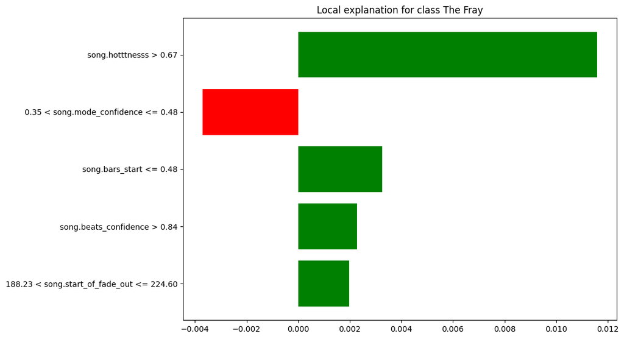

```python
local_exp.as_pyplot_figure();
```

```python
#Show local_exp data frame as a list
local_exp.as_list()
```

```
[('song.hotttnesss > 0.67', 0.011588155031316633),
 ('0.35 < song.mode_confidence <= 0.48', -0.0036932618613608006),
 ('song.bars_start <= 0.48', 0.0032607540722446684),
 ('song.beats_confidence > 0.84', 0.002275544508243457),
 ('188.23 < song.start_of_fade_out <= 224.60', 0.0019700223531347308)]
```

Quesiont 3: Call the `show_in_notebook` method to show a summary of the explanation. Set show_table = True, show_all = True

```python
local_exp.show_in_notebook(show_table = True, show_all = True)
```

[output not shown]

Question 4: Interpret the results shown by calling `show_in_notebook`. Confirm that the predicted probability shown on the left matches the predicted probability we get by calling the model directly on the instance.

```python
#Print the probabilities of the instance using the random forest model model
print(rf.predict_proba(X_test.iloc[instance_num].values.reshape(1, -1)))

# find the index of the value 0.07 in the array
expect_shakira = np.where(rf.predict_proba(X_test.iloc[instance_num].values.reshape(1, -1)) == 0.07)
print(expect_shakira[1][0])

# which class corresponse to which index
print(rf.classes_[expect_shakira[1][0]])

expect_matisyahu = np.where(rf.predict_proba(X_test.iloc[instance_num].values.reshape(1, -1)) == 0.12)
print(expect_matisyahu[1][0])
rf.classes_[expect_matisyahu[1][0]]
```

```
[[0.03 0.04 0.   0.06 0.01 0.01 0.   0.05 0.01 0.   0.03 0.   0.   0.
  0.   0.   0.   0.01 0.   0.02 0.   0.01 0.   0.   0.   0.05 0.   0.
  0.   0.   0.   0.01 0.   0.   0.   0.   0.   0.   0.   0.   0.   0.
  0.   0.   0.   0.01 0.   0.   0.   0.   0.01 0.03 0.   0.   0.   0.02
  0.   0.01 0.03 0.   0.01 0.12 0.01 0.   0.01 0.   0.01 0.01 0.   0.02
  0.   0.01 0.   0.03 0.   0.   0.02 0.05 0.   0.01 0.   0.07 0.02 0.01
  0.06 0.   0.   0.01 0.   0.   0.03 0.   0.   0.   0.   0.   0.   0.
  0.   0.03 0.   0.01 0.  ]]
81
Shakira
61
```

[output not shown]

```
'Muse'
```

The first prediction of Muse may have been wrong because of the warnings see above, but I am unsure how to fix those.

[Bonus] Question 5: Repeat the above steps with a Support Vector Machine Classifier. What conclusions to you draw about model explainablity.

```python
X, y = df_data[vars_keep], df_data['class']
X_train, X_test, Y_train, Y_test = train_test_split(X, y, test_size = 0.2, random_state = 0)
print('Training set size - X_train: {} '.format(X_train.shape))
print('Training set size - X_test: {} '.format(X_test.shape))

# Use a Support Vector Machine classifier to predict results on the same data set
from sklearn.svm import SVC
svm = SVC(probability = True, random_state = 123456)
svm.fit(X_train, Y_train)
```

```
Training set size - X_train: (316, 17)
Training set size - X_test: (79, 17)
```

```
SVC(probability=True, random_state=123456)
```

```python
explainer_svm = lime.lime_tabular.LimeTabularExplainer(X_train.values,
                                                   feature_names = X_train.columns,
                                                   class_names = Y_train.unique(),
                                                   verbose=True, discretize_continuous = True)

instance_num = 42 # because it's the answer to the ultimate question of life, the universe and everything

local_exp = explainer.explain_instance(X_test.iloc[instance_num], svm.predict_proba, num_features = 5)
print(f'Explainer score: {local_exp.score})')
```

```
Intercept 0.013023834515751356
Prediction_local [0.01340379]
Right: 0.013386574233719023
Explainer score: 0.012470650418098916)
```

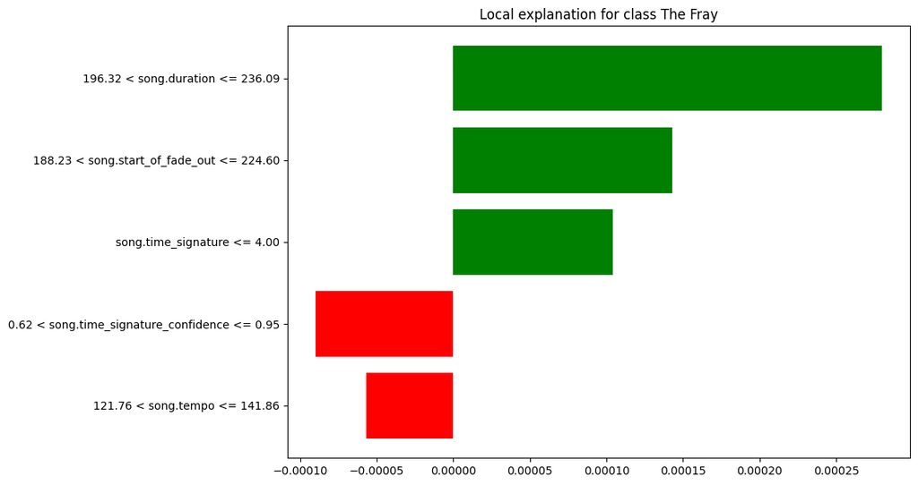

```python
local_exp.as_pyplot_figure();
```

```python
#Show local_exp data frame as a list
local_exp.as_list()
```

```
[('196.32 < song.duration <= 236.09', 0.00027974917698389486),
 ('188.23 < song.start_of_fade_out <= 224.60', 0.00014293940630525688),
 ('song.time_signature <= 4.00', 0.00010403468199315168),
 ('0.62 < song.time_signature_confidence <= 0.95', -8.97703515635049e-05),
 ('121.76 < song.tempo <= 141.86', -5.6992484423657755e-05)]
```

```python
local_exp.show_in_notebook(show_table = True, show_all = True)
```

[output not shown]

```python
#Print the probabilities of the instance using the random forest model model
print(svm.predict_proba(X_test.iloc[instance_num].values.reshape(1, -1)))

# find the index of the value 0.07 in the array
expect_mariah = np.where(svm.predict_proba(X_test.iloc[instance_num].values.reshape(1, -1)) >= 0.02727)
print(expect_mariah[1][0])

# which class corresponse to which index
print(svm.classes_[expect_mariah[1][0]])
```

```
[[0.01489514 0.01338657 0.02727778 0.01293687 0.01350375 0.01311191
  0.00634395 0.00565316 0.00553957 0.00559781 0.01431506 0.00569886
  0.01473483 0.00568731 0.00552159 0.0078765  0.00564014 0.00563238
  0.00554945 0.01114687 0.00555069 0.01469806 0.00665532 0.00572212
  0.01326888 0.00567298 0.01327456 0.00630466 0.00555989 0.00549748
  0.00903535 0.01522216 0.01302081 0.00549921 0.0059208  0.00567843
  0.00552557 0.01287256 0.00547166 0.01322826 0.00557845 0.0142287
  0.01459894 0.00563803 0.01732797 0.01509598 0.01930935 0.00572655
  0.00556828 0.00567087 0.00569142 0.01566195 0.005605   0.0058201
  0.00542457 0.00920223 0.01140329 0.01573392 0.00887521 0.00648855
  0.01435964 0.01077336 0.0134029  0.00546232 0.01328081 0.00578713
  0.01576703 0.0057599  0.00571096 0.00573139 0.00604932 0.01063557
  0.00562791 0.02255217 0.0146043  0.00562686 0.01366786 0.01171025
  0.01727634 0.00559992 0.00560583 0.02196542 0.00559286 0.01366047
  0.02024539 0.00562909 0.0060514  0.00573047 0.00544666 0.00554583
  0.00592507 0.01001965 0.01406204 0.01484326 0.0056136  0.00599618
  0.005566   0.00565358 0.01915661 0.01409602 0.00673938 0.00944565
  0.0056453 ]]
2
Aerosmith
```

The above definitely didn't go as I expected. The model prediction didn't match with what I saw from LIME.

Question 6: Create a new text cell in your Notebook: Complete a 50-100 word summary (or short description of your thinking in applying this week's learning to the solution) of your experience in this assignment. Include: What was your incoming experience with this model, if any? what steps you took, what obstacles you encountered. how you link this exercise to real-world, machine learning problem-solving. (What steps were missing? What else do you need to learn?) This summary allows your instructor to know how you are doing and allot points for your effort in thinking and planning, and making connections to real-world work.

This was an interesting exercise. I understand conceptually why we need a tool like LIME. It gives humans a good insight into how the model is making it's predictions, which features are considered important to the chosen model and gives more insight in genereral to how the chosen model is arriving at its predictions. However, I struggled with correlating the actual predictions from the model with what LIME was showing in the notebook. In fact only one of the few values that I checked from the LIME prediction matched with the model prediction.

I think there is something I didn't fundamentally understand about getting the model predictions from the model and associating them with a class. I think probably this is just a lack of understanding of how model classes are encoded in the model.

Despite this mechanical error I do understand the motivation for a tool such as LIME and I would like to spend more time getting familiar with it's model interpretations on more than just RandomForest and SVM models. I'd like to see it's capabilities on image classifiers. Would it work with something like the RESNET image classifiers?